# Analyzing Individual BGG Users

Phil Henrickson

2022-01-01

# **Rjasimmons’s** BoardGameGeek Collection

This notebook contains a set of analyses for the selected user’s boardgamegeek collection. The bulk of the analysis is focused on building a user-specific predictive model to predict the games that Rjasimmons is likely to own. This enables to ask questions like, based on the games the user currently owns, what games are a good fit for their collection? What upcoming games are they likely to purchase?

This analysis is based on data from BoardGameGeek that was last updated on **2021-12-20.**

# 1 Collection Overview

We can look at a basic description of the number of games that the user owns, has rated, has previously owned, etc.

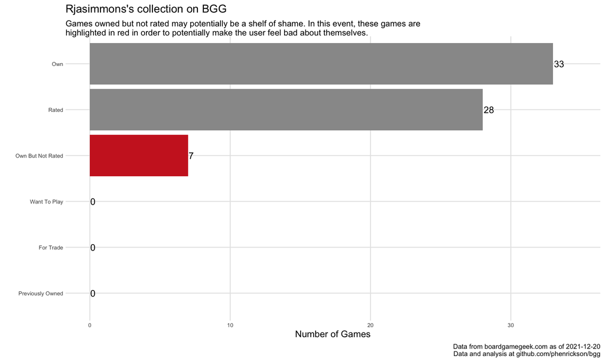

What years has the user owned/rated games from? While we can’t see when a user added or removed a game from their collection, we can look at their collection by the years in which their games were published.

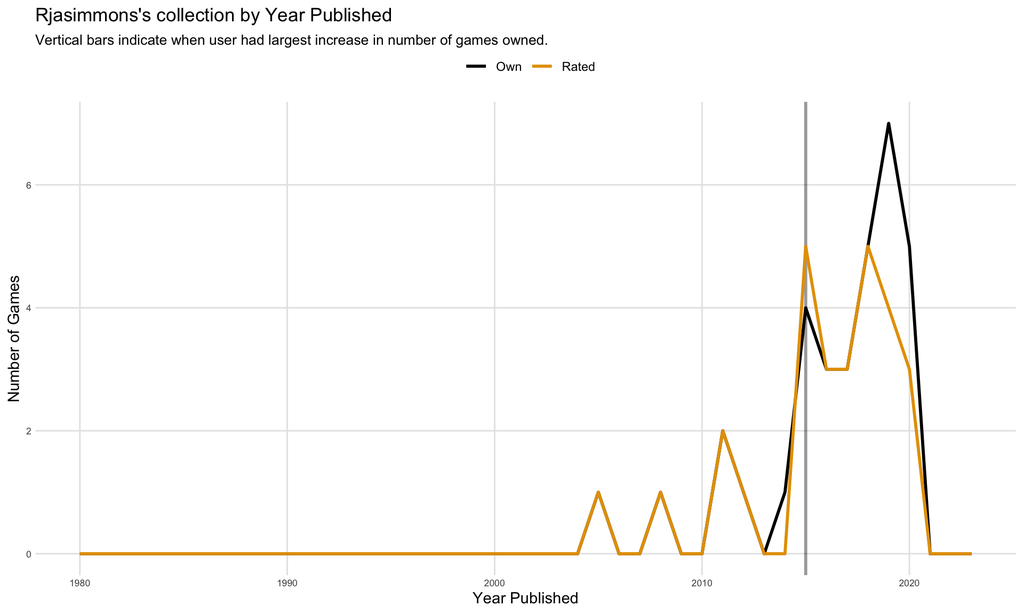

## 1.1 What types of games does Rjasimmons own?

We can look at the most frequent types of categories, mechanics, designers, and artists that appear in a user’s collection.

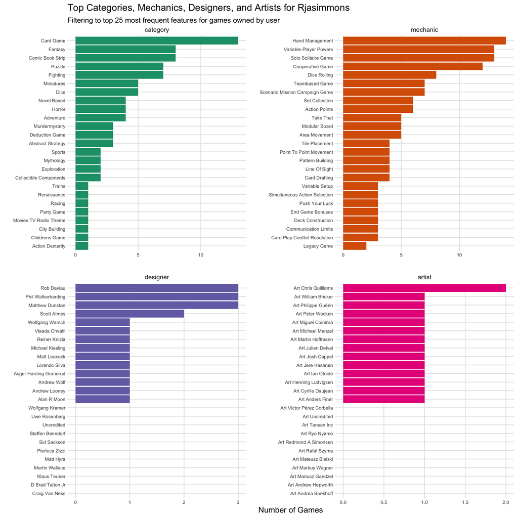

# 2 Modeling **Rjasimmons’s** Collection

| username | dataset | period | games_owned | games_rated | games_played |
| --- | --- | --- | --- | --- | --- |
| Rjasimmons | training | published before 2020 | 25 | 23 | 27 |
| Rjasimmons | test | published 2020 or later | 5 | 3 | 5 |

There are two main (binary) outcomes we will be modeling for the user.

The first, **own** refers to whether the user currently lists a game as owned in their collection. The second, **played** refers to whether the user currently owns, has rated, or previously owned a game. This means the latter will generally have a larger list of games, but may still be a useful category to examine for people who play lots of games without necessarily owning them.

We will train predictive models to learn the probability that the user will own or play individual games based on their features.

## 2.1 Coefficients for Rjasimmons

We can examine coefficients from the trained modes, which are penalized logistic regressions fit to our two main outcomes. Positive values indicate that a feature increases a user’s probabilility of owning/rating a game, while negative values indicate a feature decreases the probability.

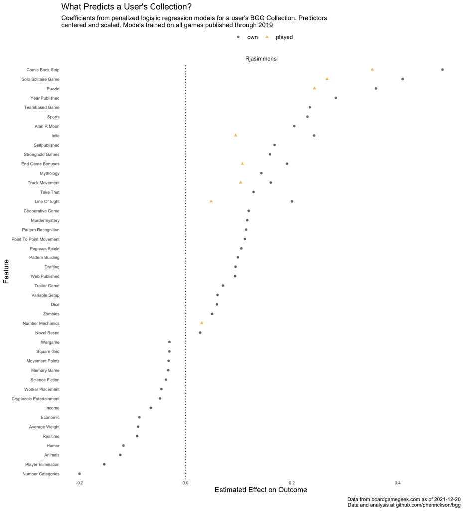

## 2.2 Visualizing Predictors for Rjasimmons’s Collection

Why did the model identify these features? We can make density plots of the important features for predicting whether the user owned a game. Blue indicates the density for games owned by the user, while grey indicates the density for games not owned by the user.

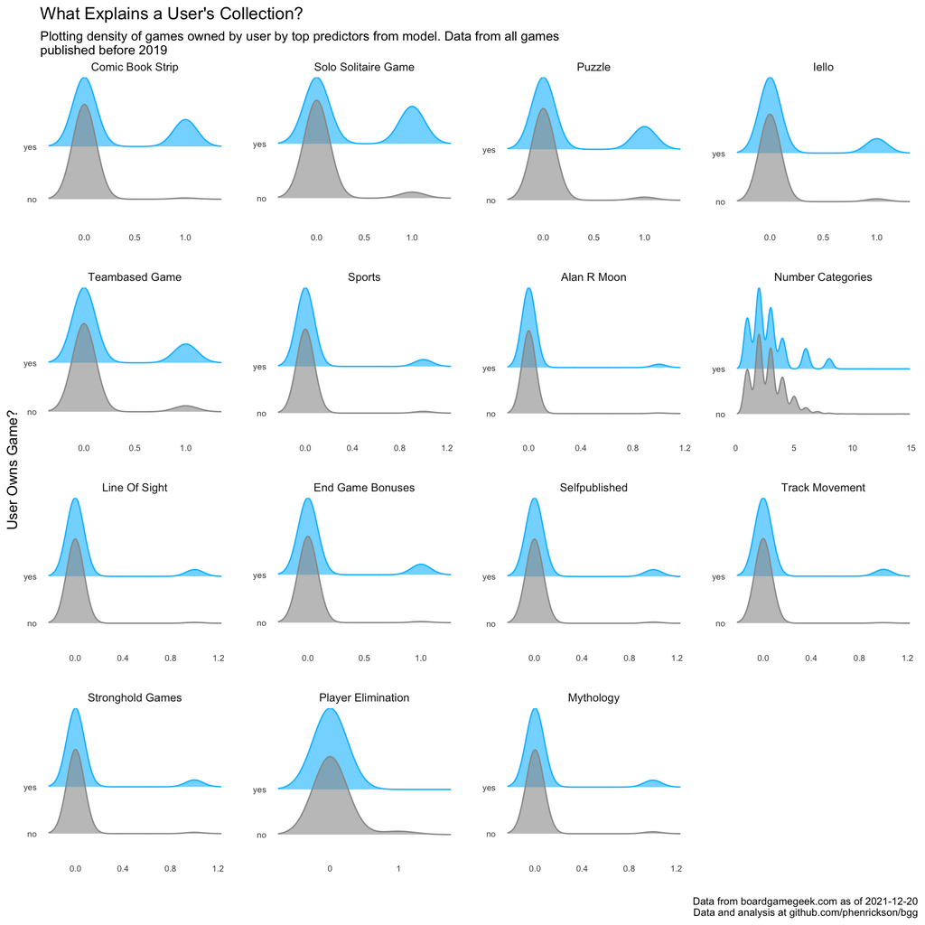

Binary predictors can be difficult to see with this visualization, so we can also directly examine the percentage of games in a user’s collection with a predictor vs the percentage of all games with that predictor.

| username | Feature | % of Games with Feature In_Collection | % of Games with Feature All_Games | Ratio |
| --- | --- | --- | --- | --- |
| Rjasimmons | Comic Book Strip | 28.0% | 1.3% | 21.6 |
| Rjasimmons | Track Movement | 8.0% | 0.6% | 12.4 |
| Rjasimmons | End Game Bonuses | 12.0% | 1.3% | 9.5 |
| Rjasimmons | Drafting | 8.0% | 1.0% | 7.7 |
| Rjasimmons | Line Of Sight | 8.0% | 1.1% | 7.4 |
| Rjasimmons | Puzzle | 24.0% | 3.3% | 7.3 |
| Rjasimmons | Solo Solitaire Game | 36.0% | 5.9% | 6.1 |
| Rjasimmons | Selfpublished | 8.0% | 1.4% | 5.6 |
| Rjasimmons | Stronghold Games | 8.0% | 1.5% | 5.3 |
| Rjasimmons | Iello | 16.0% | 3.1% | 5.1 |
| Rjasimmons | Web Published | 8.0% | 1.6% | 5.0 |
| Rjasimmons | Murdermystery | 8.0% | 1.7% | 4.6 |
| Rjasimmons | Sports | 8.0% | 2.0% | 4.0 |
| Rjasimmons | Mythology | 8.0% | 2.3% | 3.6 |
| Rjasimmons | Pegasus Spiele | 16.0% | 4.8% | 3.4 |
| Rjasimmons | Cooperative Game | 28.0% | 8.5% | 3.3 |
| Rjasimmons | Pattern Recognition | 8.0% | 2.4% | 3.3 |
| Rjasimmons | Teambased Game | 20.0% | 6.3% | 3.2 |
| Rjasimmons | Pattern Building | 12.0% | 3.8% | 3.2 |
| Rjasimmons | Take That | 16.0% | 6.7% | 2.4 |
| Rjasimmons | Point To Point Movement | 12.0% | 5.1% | 2.3 |
| Rjasimmons | Player Elimination | 0.0% | 4.1% | 0.0 |
| Rjasimmons | Animals | 0.0% | 6.9% | 0.0 |
| Rjasimmons | Humor | 0.0% | 5.7% | 0.0 |
| Rjasimmons | Realtime | 0.0% | 4.2% | 0.0 |

# 3 Assess Model’s Performance on Training Set

Before predicting games in upcoming years, we can examine how well the model did and what games it liked in the training set. In this case, we used resampling techniques (cross validation) to ensure that the model had not seen a game before making its predictions.

## 3.1 Separation Plot

An easy way to examine the performance of classification model is to view a separation plot. We plot the predicted probabilities from the model for every game (from resampling) from lowest to highest. We then overlay a blue line for any game that the user does own. A good classifier is one that is able to *separate* the blue (games owned by the user) from the white (games not owned by the user), with most of the blue occurring at the highest probabilities (right side of the chart).

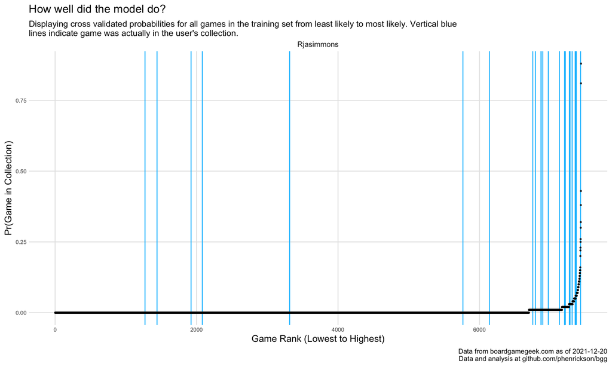

## 3.2 Top Games for **Rjasimmons** from Training Set

We can display this information in table form, displaying the 100 games with the highest probability of ownership, adding a blue line when the user does own the game.

| username | yearpublished | game_id | name | pred_played | pred_own | actual_played | actual_own |
| --- | --- | --- | --- | --- | --- | --- | --- |
| Rjasimmons | 2006 | 21241 | Neuroshima Hex! 3.0 | 0.26 | 0.88 | 0 | 0 |
| Rjasimmons | 2019 | 222514 | Batman: Gotham City Chronicles | 0.16 | 0.81 | 0 | 0 |
| Rjasimmons | 2019 | 283863 | The Magnificent | 0.03 | 0.43 | 0 | 0 |
| Rjasimmons | 2016 | 204592 | The Mysterious Forest | 0.11 | 0.38 | 0 | 0 |
| Rjasimmons | 2017 | 228570 | Raging Bulls | 0.06 | 0.32 | 0 | 0 |
| Rjasimmons | 2014 | 153097 | Heroes Wanted | 0.18 | 0.30 | 0 | 0 |
| Rjasimmons | 2011 | 102652 | Sentinels of the Multiverse | 0.05 | 0.26 | 1 | 1 |
| Rjasimmons | 2019 | 243759 | Hellboy: The Board Game | 0.09 | 0.25 | 0 | 0 |
| Rjasimmons | 2014 | 164265 | Witness | 0.05 | 0.23 | 0 | 0 |
| Rjasimmons | 2019 | 276025 | Maracaibo | 0.16 | 0.22 | 0 | 0 |
| Rjasimmons | 2011 | 99120 | The Walking Dead: The Board Game | 0.04 | 0.20 | 0 | 0 |
| Rjasimmons | 2015 | 181687 | The Pursuit of Happiness | 0.05 | 0.16 | 0 | 0 |
| Rjasimmons | 2013 | 148231 | Corto | 0.04 | 0.15 | 0 | 0 |
| Rjasimmons | 2016 | 180771 | Teenage Mutant Ninja Turtles: Shadows of the Past | 0.04 | 0.15 | 0 | 0 |
| Rjasimmons | 2018 | 252693 | Batman: The Animated Series – Gotham City Under Siege | 0.04 | 0.15 | 0 | 0 |
| Rjasimmons | 2016 | 204027 | Cottage Garden | 0.01 | 0.14 | 0 | 0 |
| Rjasimmons | 2019 | 295564 | Unmatched Game System | 0.01 | 0.14 | 0 | 0 |
| Rjasimmons | 2017 | 221368 | DC Comics Deck-Building Game: Confrontations | 0.04 | 0.14 | 0 | 0 |
| Rjasimmons | 2017 | 231999 | Finished! | 0.02 | 0.13 | 0 | 0 |
| Rjasimmons | 2019 | 244274 | The Crusoe Crew | 0.03 | 0.13 | 0 | 0 |
| Rjasimmons | 2018 | 223321 | Detective: A Modern Crime Board Game | 0.01 | 0.13 | 0 | 0 |
| Rjasimmons | 2015 | 184371 | Justice League: Hero Dice – Batman | 0.05 | 0.12 | 0 | 0 |
| Rjasimmons | 2018 | 259537 | Saint Seiya: Deckbuilding | 0.04 | 0.12 | 0 | 0 |
| Rjasimmons | 2018 | 205896 | Rising Sun | 0.01 | 0.12 | 0 | 0 |
| Rjasimmons | 2014 | 244171 | Sherlock Holmes: Four Investigations | 0.04 | 0.11 | 0 | 0 |
| Rjasimmons | 2015 | 184372 | Justice League: Hero Dice – Superman | 0.04 | 0.11 | 0 | 0 |
| Rjasimmons | 2018 | 244711 | Newton | 0.03 | 0.11 | 0 | 0 |
| Rjasimmons | 2019 | 246535 | DC Deck-Building Game: Rebirth | 0.03 | 0.11 | 0 | 0 |
| Rjasimmons | 2019 | 257066 | Sierra West | 0.16 | 0.11 | 0 | 0 |
| Rjasimmons | 2004 | 9209 | Ticket to Ride | 0.00 | 0.11 | 0 | 0 |

[output cut: 70 more lines]

We can also more formally assess how well the model did in resampling by looking at the area under the receiver operating characteristic. A perfect model would receive a score of 1, while a model that cannot predict the outcome will default to a score of 0.5. The extent to which something is a *good* score depends on the setting, but generally anything in the .8 to .9 range is very good while the .7 to .8 range is perfectly acceptable.

| username | outcome_type | .metric | .estimator | .estimate |
| --- | --- | --- | --- | --- |
| Rjasimmons | own | roc_auc | binary | 0.870 |
| Rjasimmons | played | roc_auc | binary | 0.752 |

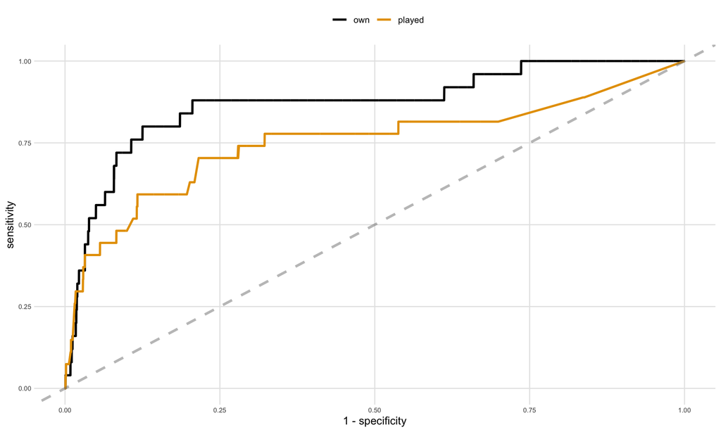

Another way to think about the model performance is to view its lift, or its ability to detect the positive outcomes over that of a null model. High lift indicates the model can much more quickly find all of the positive outcomes (in this case, games owned or played by the user), while a model with no lift is no better than random guessing.

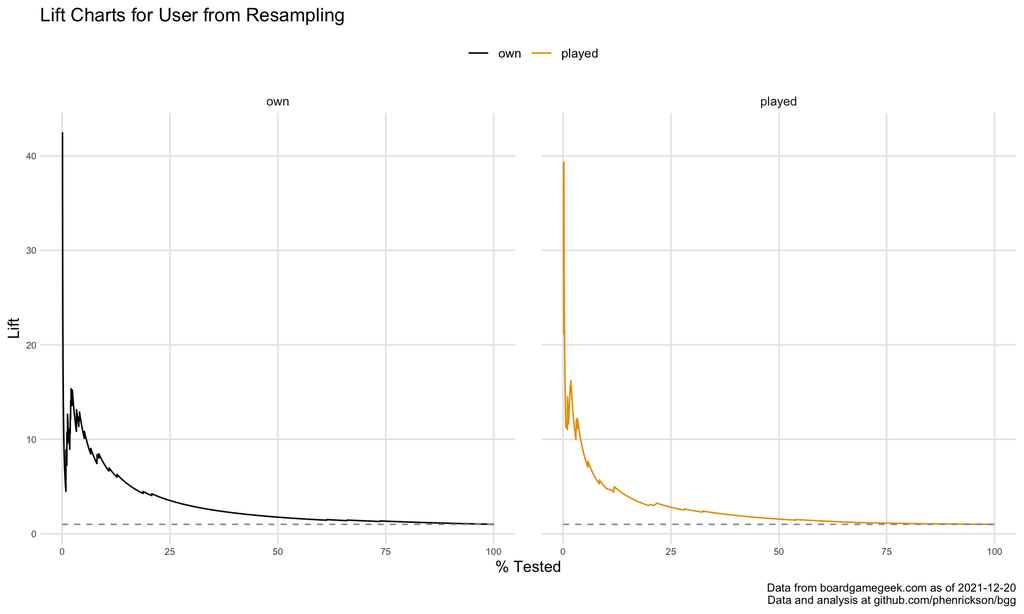

## 3.3 Most and Least Likely Games

What games does the model think Rjasimmons is **most likely to own** that are **not** in their collection?

| username | yearpublished | game_id | name | pred_own | actual_own |
| --- | --- | --- | --- | --- | --- |
| Rjasimmons | 2006 | 21241 | Neuroshima Hex! 3.0 | 0.88 | 0 |
| Rjasimmons | 2019 | 222514 | Batman: Gotham City Chronicles | 0.81 | 0 |
| Rjasimmons | 2019 | 283863 | The Magnificent | 0.43 | 0 |
| Rjasimmons | 2016 | 204592 | The Mysterious Forest | 0.38 | 0 |
| Rjasimmons | 2017 | 228570 | Raging Bulls | 0.32 | 0 |

What games does the model think Rjasimmons is **least likely to own** that **are** in their collection?

| username | yearpublished | game_id | name | pred_own | actual_own |
| --- | --- | --- | --- | --- | --- |
| Rjasimmons | 2018 | 239188 | Chronicles of Crime | 0 | 1 |
| Rjasimmons | 2019 | 284082 | Adventure Games: The Volcanic Island | 0 | 1 |
| Rjasimmons | 2011 | 95105 | 1st & Goal | 0 | 1 |
| Rjasimmons | 2008 | 30549 | Pandemic | 0 | 1 |
| Rjasimmons | 2015 | 178940 | Push It | 0 | 1 |

## 3.4 Top Games by Year

Top 25 games most likely to be owned by the user in each year, highlighting in blue the games that the user has owned/played.

| rank | 2011 | 2012 | 2013 | 2014 | 2015 | 2016 | 2017 | 2018 | 2019 |
| --- | --- | --- | --- | --- | --- | --- | --- | --- | --- |
| 1 | Sentinels of the Multiverse | Tokaido | Corto | Heroes Wanted | The Pursuit of Happiness | The Mysterious Forest | Raging Bulls | Batman: The Animated Series – Gotham City Under Siege | Batman: Gotham City Chronicles |
| 2 | The Walking Dead: The Board Game | Space Cadets | Legacy: The Testament of Duke de Crecy | Witness | Justice League: Hero Dice – Batman | Teenage Mutant Ninja Turtles: Shadows of the Past | DC Comics Deck-Building Game: Confrontations | Detective: A Modern Crime Board Game | The Magnificent |
| 3 | Munchkin Axe Cop | Munchkin Conan | Justice League: Axis of Villains Strategy Game | Sherlock Holmes: Four Investigations | Justice League: Hero Dice – Superman | Cottage Garden | Finished! | Saint Seiya: Deckbuilding | Hellboy: The Board Game |
| 4 | Penny Arcade: The Game – Gamers vs. Evil | Legends of Andor | Infection: Humanity's Last Gasp | Elevenses for One | X-Men: Mutant Revolution | Mr. Cabbagehead's Garden | Paper Tales | Rising Sun | Maracaibo |
| 5 | Space Infantry | Mini Curling Game | Heroes of Metro City | Deception: Murder in Hong Kong | Exploding Kittens | Escape the Room: Mystery at the Stargazer's Manor | Journal 29: Interactive Book Game | Newton | Unmatched Game System |
| 6 | Battle of LITS | Legendary: A Marvel Deck Building Game | Superfight | Onward to Venus | Castellion | Great Western Trail | Exit: The Game – Dead Man on the Orient Express | Hail Hydra | The Crusoe Crew |
| 7 | City Square Off | DC Comics Deck-Building Game | Lewis & Clark: The Expedition | Imperial Settlers | Bottom of the 9th | Sherlock Holmes Consulting Detective: Jack the Ripper & West End Adventures | Raxxon | Crystallo | DC Deck-Building Game: Rebirth |
| 8 | Friday | Mage Wars Arena | Batman: Arkham City Escape | DC Comics Deck-Building Game: Forever Evil | Coffee Roaster | Munchkin Marvel | Legendary Forests | Gingerbread House | Sierra West |
| 9 | Streams | Freedom: The Underground Railroad | Batman: Gotham City Strategy Game | Heroes of Normandie | Bang! The Dice Game: The Walking Dead | Batman: The Animated Series Dice Game | D100 Dungeon | Teotihuacan: City of Gods | Azul: Summer Pavilion |
| 10 | Santiago de Cuba | Hoplomachus: The Lost Cities | Dungeon Roll | Pack of Heroes | Exploding Kittens: NSFW Deck | Terraforming Mars | Munchkin X-Men | 5-Minute Marvel | Nova Luna |
| 11 | Monster Trap | Targi | Ultimate Werewolf: Inquisition | Machina Arcana | DC Comics Deck-Building Game: Teen Titans | Hit Z Road | Unlock!: Escape Adventures – Squeek & Sausage | Legendary: A Marvel Deck Building Game – Marvel Studios, Phase 1 | Tiny Towns |
| 12 | Tetris Link | Il Vecchio | Luchador! Mexican Wrestling Dice | Legendary: A Marvel Deck Building Game – Villains | Hoplomachus: Origins | OrganATTACK! | Microbrew | Arraial | Paris: La Cité de la Lumière |
| 13 | Panic Station | Penny Arcade: The Game – Rumble in R'lyeh | Band of Brothers: Ghost Panzer | DC Comics Deck-Building Game: Rivals – Batman vs The Joker | Vs System 2PCG: The Marvel Battles | Flag Dash | Fast Forward: FLEE | Village Attacks | Judge Dredd: Helter Skelter |
| 14 | Pictomania | Pick-a-Dog | The Ravens of Thri Sahashri | Castles of Mad King Ludwig | Rolling America | Encore! | Scott Pilgrim's Precious Little Card Game | Escape Tales: The Awakening | Judge Dredd: The Cursed Earth |
| 15 | Swish | Kings of War | Hoplomachus: Rise of Rome | Co-Mix | Mysterium | The Walking Dead: All Out War | Codenames: Marvel | Pax Emancipation | Marvel Fluxx |
| 16 | Mansions of Madness | Neuroshima: Convoy | Cube Quest | Smash Up: Science Fiction Double Feature | The Maiden in the Forest | Arcane Academy | Pit Crew | Thanos Rising: Avengers Infinity War | It's a Wonderful World |
| 17 | Airlines Europe | Urbion | Dawn of the Zeds (Second edition) | Patchwork | My Village | Timebomb | Legends of Andor: The Last Hope | Kick-Ass: The Board Game | The Isle of Cats |
| 18 | Pelican Cove | Tzolk'in: The Mayan Calendar | Maquis | Fields of Arle | Dadaocheng | Perdition's Mouth: Abyssal Rift | Itchy Feet: the Travel Game | Exit: The Game – The Catacombs of Horror | Era of Kingdoms |
| 19 | Colorpop | Goblins, Inc. | Pathfinder Adventure Card Game: Rise of the Runelords – Base Set | Limes | Tiny Epic Defenders | Simon's Cat Card Game | Exit: The Game – The Forgotten Island | Sprawlopolis | Yōkai |
| 20 | Band of Brothers: Screaming Eagles | Level 7 [Escape] | The Witches: A Discworld Game | Haru Ichiban | SteamRollers | Mansions of Madness: Second Edition | Exit: The Game – The Polar Station | Metro X | Diáspora |
| 21 | A Few Acres of Snow | Enigma | Eight-Minute Empire: Legends | Onirim (Second Edition) | The Game | Dawn of the Zeds (Third Edition) | Spirit Island | Pandemic: Fall of Rome | Peloponnesian War |
| 22 | Sekigahara: The Unification of Japan | Mondo Sapiens | UGO! | Hapsburg Eclipse | Warhammer Age of Sigmar | Smash Up: It's Your Fault! | Deckscape: The Fate of London | Coimbra | Adventure Games: The Dungeon |
| 23 | Fighting Formations: Grossdeutschland Motorized Infantry Division | Robinson Crusoe: Adventures on the Cursed Island | Zen Garden | The Draugr | ...and then, we held hands. | Pentaquark | Bears vs Babies | Realm of Sand | Exit: The Game – The Stormy Flight |
| 24 | No Retreat! The Russian Front | Panzer: The Game of Small Unit Actions and Combined Arms Operations on the Eastern Front 1943-45 | The Phantom Society | Rolling Japan | Die Legenden von Andor: Chada & Thorn | Exit: The Game – The Pharaoh's Tomb | Aristeia! | Azul: Stained Glass of Sintra | Talisman: Batman – Super-Villains Edition |
| 25 | Nightfighter | Bolt Action | Space Sheep! | Kaosball: The Fantasy Sport of Total Domination | Star Realms: Colony Wars | Of Dreams & Shadows | Smash Up: What Were We Thinking? | Raids | HATE |

## 3.5 Interactive Predictions from Resampling

Interactive table for predictions from resampling.

|  | username | yearpublished | rank | game_id | name | pred_played | pred_own | actual_played | actual_own |
| --- | --- | --- | --- | --- | --- | --- | --- | --- | --- |
| 1 | Rjasimmons | 1900 | 59 | 10799 | Old Maid | 0.06 | 0.07 | 0 | 0 |
| 2 | Rjasimmons | 1900 | 158 | 2136 | Pachisi | 0.03 | 0.03 | 0 | 0 |
| 3 | Rjasimmons | 1900 | 304 | 2083 | Checkers | 0.04 | 0.01 | 0 | 0 |
| 4 | Rjasimmons | 1900 | 749 | 5546 | Marbles | 0 | 0 | 0 | 0 |
| 5 | Rjasimmons | 1900 | 751 | 11901 | Tic-Tac-Toe | 0 | 0 | 0 | 0 |
| 6 | Rjasimmons | 1900 | 794 | 188 | Go | 0 | 0 | 0 | 0 |
| 7 | Rjasimmons | 1900 | 907 | 171 | Chess | 0 | 0 | 0 | 0 |
| 8 | Rjasimmons | 1900 | 918 | 2065 | Shogi | 0 | 0 | 0 | 0 |
| 9 | Rjasimmons | 1900 | 920 | 2393 | Xiangqi | 0 | 0 | 0 | 0 |
| 10 | Rjasimmons | 1900 | 1134 | 26952 | International Checkers | 0 | 0 | 0 | 0 |

[output cut: 7426 more lines]

# 4 Validating the Model on 2020

How well did a model trained on a user’s collection through 2019 perform in predicting games for the user from 2020?

| username | outcome_type | yearpublished | .metric | .estimator | .estimate |
| --- | --- | --- | --- | --- | --- |
| Rjasimmons | own | 2020 | roc_auc | binary | 0.918 |
| Rjasimmons | played | 2020 | roc_auc | binary | 0.837 |

Table of top 25 games from 2020, highlighting games that the user owns.

| username | yearpublished | game_id | name | pred_own | pred_played | actual_own | actual_played |
| --- | --- | --- | --- | --- | --- | --- | --- |
| Rjasimmons | 2020 | 304728 | SpongeBob SquarePants: Plankton Rising | 0.31 | 0.12 | 0 | 0 |
| Rjasimmons | 2020 | 298047 | Marvel United | 0.30 | 0.12 | 0 | 0 |
| Rjasimmons | 2020 | 308329 | The Batman Who Laughs Rising | 0.29 | 0.13 | 0 | 0 |
| Rjasimmons | 2020 | 253807 | The Few and Cursed | 0.22 | 0.12 | 0 | 0 |
| Rjasimmons | 2020 | 257145 | Teenage Mutant Ninja Turtles Adventures: City Fall | 0.18 | 0.05 | 0 | 0 |
| Rjasimmons | 2020 | 229782 | Roland Wright: The Dice Game | 0.13 | 0.03 | 0 | 0 |
| Rjasimmons | 2020 | 253506 | Versailles 1919 | 0.13 | 0.06 | 0 | 0 |
| Rjasimmons | 2020 | 263192 | Teenage Mutant Ninja Turtles Adventures: Change is Constant | 0.13 | 0.05 | 0 | 0 |
| Rjasimmons | 2020 | 293531 | Detective: A Modern Crime Board Game – Season One | 0.11 | 0.01 | 0 | 0 |
| Rjasimmons | 2020 | 294484 | Unmatched: Cobble & Fog | 0.11 | 0.01 | 1 | 1 |
| Rjasimmons | 2020 | 304285 | Infinity Gauntlet: A Love Letter Game | 0.11 | 0.04 | 0 | 0 |
| Rjasimmons | 2020 | 308765 | Praga Caput Regni | 0.11 | 0.08 | 0 | 0 |
| Rjasimmons | 2020 | 315954 | Hunt A Killer: Death at the Dive Bar | 0.11 | 0.03 | 0 | 0 |
| Rjasimmons | 2020 | 325635 | Unmatched: Little Red Riding Hood vs. Beowulf | 0.11 | 0.01 | 0 | 0 |
| Rjasimmons | 2020 | 316555 | The Umbrella Academy Game | 0.09 | 0.04 | 0 | 0 |
| Rjasimmons | 2020 | 318977 | MicroMacro: Crime City | 0.09 | 0.01 | 1 | 1 |
| Rjasimmons | 2020 | 304420 | Bonfire | 0.07 | 0.03 | 0 | 0 |
| Rjasimmons | 2020 | 307844 | Atheneum: Mystic Library | 0.07 | 0.02 | 0 | 0 |
| Rjasimmons | 2020 | 263085 | Darksiders: The Forbidden Land | 0.06 | 0.04 | 0 | 0 |
| Rjasimmons | 2020 | 298607 | Crime Story: Vienna | 0.06 | 0.03 | 0 | 0 |
| Rjasimmons | 2020 | 304021 | Lost in Valhalla | 0.06 | 0.01 | 0 | 0 |
| Rjasimmons | 2020 | 306687 | Get Out of Colditz: The Card Game | 0.06 | 0.01 | 0 | 0 |
| Rjasimmons | 2020 | 315138 | Autumn Harvest: A Tea Dragon Society Game | 0.06 | 0.04 | 0 | 0 |
| Rjasimmons | 2020 | 269403 | LOTS: A Competitive Tower Building Game | 0.05 | 0.03 | 0 | 0 |
| Rjasimmons | 2020 | 302193 | Wonder Woman: Challenge of the Amazons | 0.05 | 0.04 | 0 | 0 |

# 5 Predicting Upcoming Games (2020 and On) for **Rjasimmons**

Examine the top games for the test set.

| username | yearpublished | game_id | name | rank | own | played |
| --- | --- | --- | --- | --- | --- | --- |
| Rjasimmons | 2020 | 304728 | SpongeBob SquarePants: Plankton Rising | 1 | 0.31 | 0.12 |
| Rjasimmons | 2020 | 298047 | Marvel United | 2 | 0.30 | 0.12 |
| Rjasimmons | 2020 | 308329 | The Batman Who Laughs Rising | 3 | 0.29 | 0.13 |
| Rjasimmons | 2020 | 253807 | The Few and Cursed | 4 | 0.22 | 0.12 |
| Rjasimmons | 2020 | 257145 | Teenage Mutant Ninja Turtles Adventures: City Fall | 5 | 0.18 | 0.05 |
| Rjasimmons | 2020 | 263192 | Teenage Mutant Ninja Turtles Adventures: Change is Constant | 6 | 0.13 | 0.05 |
| Rjasimmons | 2020 | 253506 | Versailles 1919 | 7 | 0.13 | 0.06 |
| Rjasimmons | 2020 | 229782 | Roland Wright: The Dice Game | 8 | 0.13 | 0.03 |
| Rjasimmons | 2020 | 325635 | Unmatched: Little Red Riding Hood vs. Beowulf | 9 | 0.11 | 0.01 |
| Rjasimmons | 2020 | 294484 | Unmatched: Cobble & Fog | 10 | 0.11 | 0.01 |
| Rjasimmons | 2020 | 293531 | Detective: A Modern Crime Board Game – Season One | 11 | 0.11 | 0.01 |
| Rjasimmons | 2020 | 308765 | Praga Caput Regni | 12 | 0.11 | 0.08 |
| Rjasimmons | 2020 | 304285 | Infinity Gauntlet: A Love Letter Game | 13 | 0.11 | 0.04 |
| Rjasimmons | 2020 | 315954 | Hunt A Killer: Death at the Dive Bar | 14 | 0.11 | 0.03 |
| Rjasimmons | 2020 | 316555 | The Umbrella Academy Game | 15 | 0.09 | 0.04 |
| Rjasimmons | 2020 | 318977 | MicroMacro: Crime City | 16 | 0.09 | 0.01 |
| Rjasimmons | 2020 | 307844 | Atheneum: Mystic Library | 17 | 0.07 | 0.02 |
| Rjasimmons | 2020 | 304420 | Bonfire | 18 | 0.07 | 0.03 |
| Rjasimmons | 2020 | 304021 | Lost in Valhalla | 19 | 0.06 | 0.01 |
| Rjasimmons | 2020 | 315138 | Autumn Harvest: A Tea Dragon Society Game | 20 | 0.06 | 0.04 |
| Rjasimmons | 2020 | 306687 | Get Out of Colditz: The Card Game | 21 | 0.06 | 0.01 |
| Rjasimmons | 2020 | 263085 | Darksiders: The Forbidden Land | 22 | 0.06 | 0.04 |
| Rjasimmons | 2020 | 298607 | Crime Story: Vienna | 23 | 0.06 | 0.03 |
| Rjasimmons | 2020 | 269403 | LOTS: A Competitive Tower Building Game | 24 | 0.05 | 0.03 |
| Rjasimmons | 2020 | 302193 | Wonder Woman: Challenge of the Amazons | 25 | 0.05 | 0.04 |
| Rjasimmons | 2021 | 277469 | The Phantom: The Card Game | 1 | 0.63 | 0.12 |
| Rjasimmons | 2021 | 336382 | Marvel United: X-Men | 2 | 0.52 | 0.13 |
| Rjasimmons | 2021 | 299566 | Batman: The Animated Series Adventures – Shadow of the Bat | 3 | 0.50 | 0.13 |
| Rjasimmons | 2021 | 315937 | X-Men: Mutant Insurrection | 4 | 0.37 | 0.12 |
| Rjasimmons | 2021 | 328908 | The Initiative | 5 | 0.35 | 0.15 |
| Rjasimmons | 2021 | 304983 | Key Enigma: Hack Forward | 6 | 0.27 | 0.03 |
| Rjasimmons | 2021 | 282776 | Tumble Town | 7 | 0.26 | 0.07 |
| Rjasimmons | 2021 | 298102 | Roll Camera!: The Filmmaking Board Game | 8 | 0.25 | 0.07 |
| Rjasimmons | 2021 | 299255 | Vienna Connection | 9 | 0.14 | 0.01 |
| Rjasimmons | 2021 | 314589 | Night Parade of a Hundred Yokai | 10 | 0.12 | 0.01 |
| Rjasimmons | 2021 | 323898 | Doom Machine | 11 | 0.12 | 0.02 |
| Rjasimmons | 2021 | 295947 | Cascadia | 12 | 0.12 | 0.03 |
| Rjasimmons | 2021 | 319263 | One Card Dungeon | 13 | 0.11 | 0.03 |
| Rjasimmons | 2021 | 284653 | Mind MGMT: The Psychic Espionage “Game.” | 14 | 0.11 | 0.04 |
| Rjasimmons | 2021 | 319899 | Decktective: Nightmare in the Mirror | 15 | 0.10 | 0.03 |
| Rjasimmons | 2021 | 206757 | Glory: A Game of Knights | 16 | 0.09 | 0.02 |
| Rjasimmons | 2021 | 338834 | MicroMacro: Crime City – Full House | 17 | 0.09 | 0.01 |
| Rjasimmons | 2021 | 306697 | Smash Up: Marvel | 18 | 0.09 | 0.04 |
| Rjasimmons | 2021 | 315624 | World Changers | 19 | 0.07 | 0.02 |
| Rjasimmons | 2021 | 340677 | Bad Company | 20 | 0.07 | 0.03 |
| Rjasimmons | 2021 | 279087 | Zerywia | 21 | 0.06 | 0.01 |
| Rjasimmons | 2021 | 291847 | Mantis Falls | 22 | 0.06 | 0.00 |
| Rjasimmons | 2021 | 339484 | Savannah Park | 23 | 0.06 | 0.03 |
| Rjasimmons | 2021 | 265771 | Dance Card! | 24 | 0.06 | 0.01 |
| Rjasimmons | 2021 | 337690 | Escape Room: The Game – Puzzle Adventures: Secret of The Scientist | 25 | 0.06 | 0.03 |
| Rjasimmons | 2022 | 317511 | Tindaya | 1 | 0.21 | 0.02 |
| Rjasimmons | 2022 | 284118 | Mechanical Beast | 2 | 0.15 | 0.03 |
| Rjasimmons | 2022 | 334065 | Verdant | 3 | 0.14 | 0.03 |
| Rjasimmons | 2022 | 295374 | Long Shot: The Dice Game | 4 | 0.12 | 0.02 |
| Rjasimmons | 2022 | 326945 | Castles of Mad King Ludwig: Collector's Edition | 5 | 0.05 | 0.02 |
| Rjasimmons | 2022 | 331401 | Dog Park | 6 | 0.05 | 0.02 |
| Rjasimmons | 2022 | 335427 | Wild: Serengeti | 7 | 0.03 | 0.02 |
| Rjasimmons | 2022 | 319807 | Shogun no Katana | 8 | 0.03 | 0.02 |
| Rjasimmons | 2022 | 280726 | Legacies | 9 | 0.02 | 0.02 |
| Rjasimmons | 2022 | 324090 | Scarface 1920 | 10 | 0.02 | 0.02 |
| Rjasimmons | 2022 | 304051 | Creature Comforts | 11 | 0.02 | 0.02 |
| Rjasimmons | 2022 | 305096 | Endless Winter: Paleoamericans | 12 | 0.02 | 0.02 |
| Rjasimmons | 2022 | 340325 | Vagrantsong | 13 | 0.01 | 0.00 |
| Rjasimmons | 2022 | 258779 | Planet Unknown | 14 | 0.01 | 0.01 |
| Rjasimmons | 2022 | 333255 | Keep the Heroes Out! | 15 | 0.01 | 0.00 |
| Rjasimmons | 2022 | 312959 | Rallyman: DIRT | 16 | 0.01 | 0.01 |
| Rjasimmons | 2022 | 303731 | Primal: The Awakening | 17 | 0.01 | 0.01 |
| Rjasimmons | 2022 | 311988 | Frostpunk: The Board Game | 18 | 0.01 | 0.01 |
| Rjasimmons | 2022 | 286063 | The 7th Citadel | 19 | 0.01 | 0.01 |
| Rjasimmons | 2022 | 331106 | The Witcher: Old World | 20 | 0.01 | 0.01 |
| Rjasimmons | 2022 | 219650 | Arydia: The Paths We Dare Tread | 21 | 0.01 | 0.01 |
| Rjasimmons | 2022 | 320718 | Hidden Leaders | 22 | 0.01 | 0.01 |
| Rjasimmons | 2022 | 294529 | Entropia: The Game | 23 | 0.01 | 0.01 |
| Rjasimmons | 2022 | 342246 | Feuding Foodies | 24 | 0.01 | 0.00 |
| Rjasimmons | 2022 | 253759 | Paint the Roses | 25 | 0.01 | 0.01 |

## 5.1 Interactive Table for Upcoming Games 2020 and On

|  | username | yearpublished | game_id | name | rank | own | played |
| --- | --- | --- | --- | --- | --- | --- | --- |
| 1 | Rjasimmons | 2021 | 277469 | The Phantom: The Card Game | 1 | 0.63 | 0.12 |
| 2 | Rjasimmons | 2021 | 336382 | Marvel United: X-Men | 2 | 0.52 | 0.13 |
| 3 | Rjasimmons | 2021 | 299566 | Batman: The Animated Series Adventures – Shadow of the Bat | 3 | 0.5 | 0.13 |
| 4 | Rjasimmons | 2021 | 315937 | X-Men: Mutant Insurrection | 4 | 0.37 | 0.12 |
| 5 | Rjasimmons | 2021 | 328908 | The Initiative | 5 | 0.35 | 0.15 |
| 6 | Rjasimmons | 2020 | 304728 | SpongeBob SquarePants: Plankton Rising | 6 | 0.31 | 0.12 |
| 7 | Rjasimmons | 2020 | 298047 | Marvel United | 7 | 0.3 | 0.12 |
| 8 | Rjasimmons | 2020 | 308329 | The Batman Who Laughs Rising | 8 | 0.29 | 0.13 |
| 9 | Rjasimmons | 2021 | 304983 | Key Enigma: Hack Forward | 9 | 0.27 | 0.03 |
| 10 | Rjasimmons | 2021 | 282776 | Tumble Town | 10 | 0.26 | 0.07 |

[output cut: 1627 more lines]